# Project_3

Aggeliki Papadopoulou

15/1/2023

## Data Wrangling

Σκοπός της εργασίας είναι η διερεύνηση των δεδομένων λιανεμπορίου (Exploratory Data Analysis). Ειδικότερα θα πρέπει να διαχειριστείτε τα διαθέσιμα δεδομένα ώστε να παραχθούν γραφικές παραστάσεις συνοδευόμενες από σχολιασμό θα πρέπει να απαντούν στα ερωτήματα.

Categories.csv: Τα προϊόντα (ean) είναι οργανωμένα σε προϊοντικές κατηγορίες 4 επιπέδων. Απεικονίζει μια δενδροειδή δομή οργάνωση των προϊόντων. Κάθε μια γραμμή είναι ένα προϊόν και τα δεδομένα που ακολουθούν είναι το μονοπάτι από μια γενική προϊοντική κατηγορία σε μια ειδίκευση.

Sales_464.csv (και Sales_493.csv): Περιέχει τις πωλήσεις που έχουν γίνει σε κάθε κατάστημα για διάστημα περίπου 12 μηνών.

### Insert Data

```r
library(ggplot2)
library(dplyr)
library("data.table")
options(knitr.duplicate.label = "allow")
categories_df = read.csv("C:\\Users\\Intel PC G5900\\Desktop\\Aggeliki_Papadopoulou\\Data\\Categories.csv",row.names=NULL, encoding="UTF-8",sep=";", stringsAsFactors=FALSE,header = TRUE)
sales_464_df = read.csv("C:\\Users\\Intel PC G5900\\Desktop\\Aggeliki_Papadopoulou\\Data\\Sales_464.csv",sep=";")
sales_493_df = read.csv("C:\\Users\\Intel PC G5900\\Desktop\\Aggeliki_Papadopoulou\\Data\\Sales_493.csv",sep=";")
```

### Print the dimensions of the three dataframes

```r
print(dim(categories_df))
```

```
## [1] 840410     11
```

```r
print(dim(sales_464_df))
```

```
## [1] 2039403       6
```

```r
print(dim(sales_493_df))
```

```
## [1] 2017693       6
```

```r
print(head(categories_df , 5))
```

```
##   X.U.FEFF.Retailer_SKU EAN                         Description Cat1_code
## 1                   112 112         ΕΙΔΟΣ ΕΚΤΟΣ ΣΥΛΛΟΓΗΣ (ΝΕΡΟ)        10
## 2                   113 113 ΕΙΔΟΣ ΕΚΤ ΣΥΛΛ(ΠΟΤΑ-ΜΠΥΡ-XYM-ANAΨΥ)        10
## 3                   117 117   ΕΙΔΟΣ ΕΚΤΟΣ ΣΥΛΛΟΓΗΣ(ΚΕΝΑ-ΦΙΑΛΕΣ)        10
## 4                   122 122 ΕΙΔΟΣ ΕΚΤΟΣ ΣΥΛΛΟΓΗΣ(ΕΙΔΗ ΥΓΙΕΙΝΗΣ)        10
## 5                   123 123 ΕΙΔΟΣ ΕΚΤΟΣ ΣΥΛΛΟΓΗΣ(ΑΠΟΡΡΥΠ-ΚΑΛΛΥ)        10
##   Cat1_name Cat2_code     Cat2_name Cat3_Code                 Cat3_name
## 1       PGC        11          ΠΟΤΑ       261                ΑΝΑΨΥΚΤΙΚΑ
## 2       PGC        11          ΠΟΤΑ       262             ΜΠΥΡΑ,ΜΗΛΙΤΗΣ
## 3       PGC        11          ΠΟΤΑ       262             ΜΠΥΡΑ,ΜΗΛΙΤΗΣ
## 4       PGC        12 ΑΠΟΡΡΥΠΑΝΤΙΚΑ       285 ΕΙΔΗ ΥΓΙΕΙΝΗΣ - ΚΑΛΛΥΝΤΙΚ
## 5       PGC        12 ΑΠΟΡΡΥΠΑΝΤΙΚΑ       281             ΑΠΟΡΡΥΠΑΝΤΙΚΑ
##   Cat4_Code                 Cat4_name
## 1         3        ΔΙΑΦΟΡΑ ΑΝΑΨΥΚΤΙΚΑ
## 2         1                     ΜΠΥΡΑ
## 3         4                      ΚΕΝΑ
## 4         1 ΑΦΡΟΛΟΥΤΡΑ-ΝΤΟΥΣ-ΣΦΟΥΓΓΑΡ
## 5         1      ΑΠΟΡΡΥΠΑΝΤΙΚΑ ΡΟΥΧΩΝ
```

```r
print(head(sales_464_df , 5))
```

```
##   ο.Ώbasket_id store  date_trns          ean quantity price
## 1   1000128586   464 2012-05-31 520103740279    1.000 1.170
## 2   1000128586   464 2012-05-31 520103740278    1.000 1.170
## 3   1000128587   464 2012-05-31 210584600000    1.062 1.369
## 4   1000128588   464 2012-05-31 520217800117    2.000 3.120
## 5   1000128588   464 2012-05-31 520100200761    1.000 2.320
```

```r
print(head(sales_493_df , 5))
```

```
##   ο.Ώbasket_id store  date_trns          ean quantity price
## 1   1000137850   493 2012-05-31 520423930919     1.00 2.100
## 2   1000137850   493 2012-05-31 212839500000     0.77 5.482
## 3   1000137850   493 2012-05-31 356007002153     1.00 0.650
## 4   1000137850   493 2012-05-31 520423931236     1.00 2.250
## 5   1000137850   493 2012-05-31 520423931268     1.00 0.850
```

### Print the column names of each dataframe

```r
print(colnames(categories_df))
```

```
##  [1] "X.U.FEFF.Retailer_SKU" "EAN"                   "Description"
##  [4] "Cat1_code"             "Cat1_name"             "Cat2_code"
##  [7] "Cat2_name"             "Cat3_Code"             "Cat3_name"
## [10] "Cat4_Code"             "Cat4_name"
```

```r
print(colnames(sales_464_df))
```

```
## [1] "ο.Ώbasket_id" "store"        "date_trns"    "ean"          "quantity"
## [6] "price"
```

```r
print(colnames(sales_493_df))
```

```
## [1] "ο.Ώbasket_id" "store"        "date_trns"    "ean"          "quantity"
## [6] "price"
```

### Print the types of each dataframe

```r
print(sapply(categories_df, typeof))
```

```
## X.U.FEFF.Retailer_SKU                   EAN           Description
##             "integer"              "double"           "character"
##             Cat1_code             Cat1_name             Cat2_code
##             "integer"           "character"             "integer"
##             Cat2_name             Cat3_Code             Cat3_name
##           "character"             "integer"           "character"
##             Cat4_Code             Cat4_name
##             "integer"           "character"
```

```r
print(sapply(sales_464_df, typeof))
```

```
## ο.Ώbasket_id        store    date_trns          ean     quantity        price
##     "double"     "double"  "character"     "double"     "double"     "double"
```

```r
print(sapply(sales_493_df, typeof))
```

```
## ο.Ώbasket_id        store    date_trns          ean     quantity        price
##     "double"     "double"  "character"     "double"     "double"     "double"
```

### Group by ean and sum quantity and price

```r
agg_tbl <- sales_464_df %>% group_by(ean) %>%
  summarise(total_price=sum(price),
            total_quantity = sum(quantity),.groups = 'drop')

sales_464_grouped_df <- agg_tbl %>% as.data.frame()
```

### Sort by quantity in descending order and keep the top 20% of quantity sales

```r
sales_464_sortedbyQyantity_df = sales_464_grouped_df[order(-sales_464_grouped_df$total_quantity),]
sales_464_20_perc = head(sales_464_sortedbyQyantity_df, round(dim(sales_464_sortedbyQyantity_df)[1] *0.2))
```

### Keep from the initial dataframe only the codes of the ean column after keeping only the top 20%

```r
list= sales_464_20_perc$ean
filtered_sales_464_df = sales_464_df[sales_464_df$ean %in% list ,]
```

### Group by date and sum prices in the filtered dataframe and sort by date in ascending order

```r
agg_tbl <- filtered_sales_464_df %>% group_by(date_trns) %>%
  summarise(total_price=sum(price),.groups = 'drop')

sales_464_grouped_df <- agg_tbl %>% as.data.frame()
sales_464_sorted_df = sales_464_grouped_df[order(sales_464_grouped_df$date_trns),]
```

### Convert date_trns from character to date

```r
sales_464_sorted_df$date_trns <- as.Date(sales_464_sorted_df$date_trns, "%Y-%m-%d")
```

## Create and print scatterplot

1. Sample of 50 points in a scatterplot of the daily revenue of top 20% of the products in terms of quantity count.

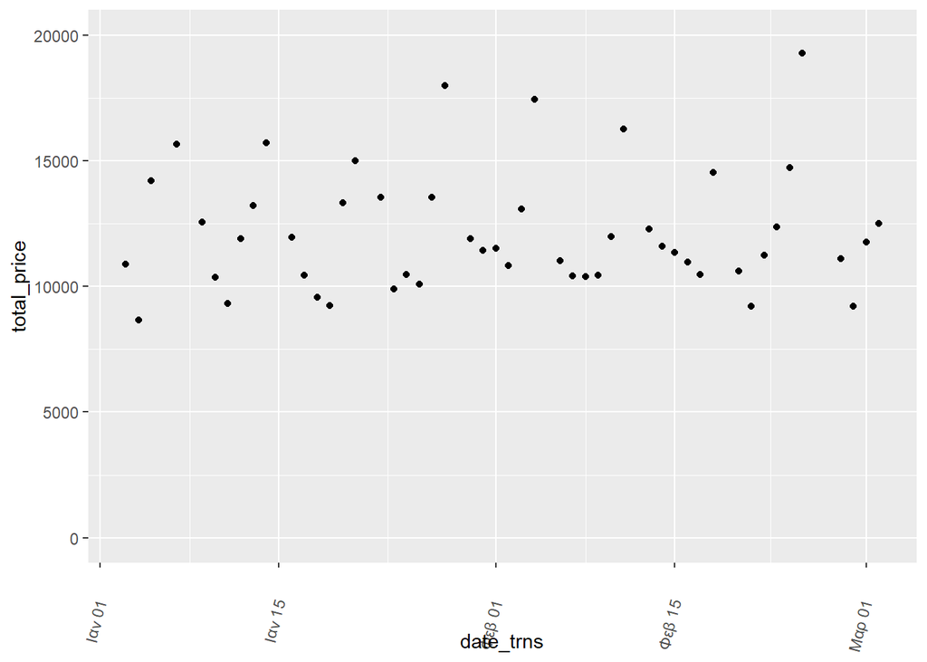

# Convert date_trns from character to date to inital dataframe

```r
sales_464_df$date_trns = as.Date(sales_464_df$date_trns, "%Y-%m-%d")
```

#Create a column for month and week number of the date

```r
sales_464_df$month =format(sales_464_df$date_trns, "%b")
sales_464_df$weekNum =format(sales_464_df$date_trns, "%V")
```

# Group by month in the dataframe and sum prices and quantity

```r
agg_tbl <- sales_464_df %>% group_by(month) %>%
  summarise(total_price=sum(price),
            total_quantity = sum(quantity),.groups = 'drop')

sales_464_grouped_month_df <- agg_tbl %>% as.data.frame()
```

# Create and print barplot

1. Monthly revenue of store 464 in a barplot.

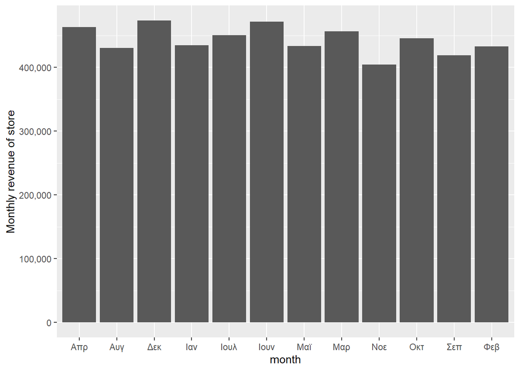